# Heart Disease Detection and Indicators

# Introduction

Our project focuses on creating a predictive model for identifying heart disease indicators and risk factors. Heart disease is a major public health concern, being a leading cause of death in the United States for various racial groups. With approximately 47% of Americans possessing at least one of three significant risk factors—high blood pressure, high cholesterol, and smoking—early detecion and risk factor prevention are vital. We will harness a healthcare datasets, primarily derived from the CDC’s Behavioral Risk Factor Surveillance System (BRFSS), to work with heart disease indicators and associated risk factors.

# Problem Statement

Our task is to find the key indicators/risk factors that will predict if an individual has had an heart attack.

# Setup

This notebook uses several packages — make sure you have installed them with `install.packages()` or the package installer in RStudio before trying to run the code in this notebook.

```r
library(tidyverse, warn.conflicts =FALSE)
library(rsample, warn.conflicts=FALSE)
library(yardstick, warn.conflicts=FALSE)
# library(rpart, warn.conflicts=FALSE)
# library(bnlearn, warn.conflicts=FALSE)
library(xgboost, warn.conflicts=FALSE)
# library(dplyr, warn.conflicts = FALSE)
# library(stringr, warn.conflicts = FALSE)
library(randomForest, warn.conflicts = FALSE)
```

```r
set.seed(20231207)
```

# Load and Prepare the Data

Load the data and read the csv file

## Load the data

```r
# Change this path to your data path
heart_raw <- read_csv("heart_2022_no_nans.csv")
glimpse(heart_raw)
```

```
Rows: 246,022
Columns: 40
$ State                     <chr> "Alabama", "Alabama", "Alabama", "Alabama", "Alabama", "Alabama", "Al…
$ Sex                       <chr> "Female", "Male", "Male", "Female", "Female", "Male", "Female", "Male…
$ GeneralHealth             <chr> "Very good", "Very good", "Very good", "Fair", "Good", "Good", "Good"…
$ PhysicalHealthDays        <dbl> 4, 0, 0, 5, 3, 0, 3, 5, 2, 0, 0, 3, 5, 0, 25, 0, 0, 0, 0, 30, 30, 4, …
$ MentalHealthDays          <dbl> 0, 0, 0, 0, 15, 0, 0, 0, 0, 0, 0, 4, 0, 0, 25, 15, 0, 0, 0, 0, 0, 0, …
$ LastCheckupTime           <chr> "Within past year (anytime less than 12 months ago)", "Within past ye…
$ PhysicalActivities        <chr> "Yes", "Yes", "No", "Yes", "Yes", "Yes", "Yes", "Yes", "No", "Yes", "…
$ SleepHours                <dbl> 9, 6, 8, 9, 5, 7, 8, 8, 6, 7, 8, 5, 5, 6, 6, 8, 7, 10, 6, 9, 8, 10, 9…
$ RemovedTeeth              <chr> "None of them", "None of them", "6 or more, but not all", "None of th…
$ HadHeartAttack            <chr> "No", "No", "No", "No", "No", "No", "No", "Yes", "No", "No", "No", "N…
$ HadAngina                 <chr> "No", "No", "No", "No", "No", "No", "No", "Yes", "No", "No", "No", "N…
$ HadStroke                 <chr> "No", "No", "No", "No", "No", "No", "Yes", "No", "No", "No", "No", "N…
$ HadAsthma                 <chr> "No", "No", "No", "No", "No", "No", "No", "No", "No", "Yes", "No", "N…
```

[output cut: 27 more lines]

## Prepare the data

### Removing certain features

I removed the following features because the association to heart disease are insignificant or some of them are not directly associated such as having arthritis could mean that taking an arthritis medication has some indirect cause for heart disease but this would mean we need more data on what kind of medication used.

```r
heart = heart_raw  %>%
  select(-PneumoVaxEver, -FluVaxLast12, -HIVTesting) %>%
  select(-HadSkinCancer, -HadArthritis)
glimpse(heart)
```

```
Rows: 246,022
Columns: 35
$ State                     <chr> "Alabama", "Alabama", "Alabama", "Alabama", "Alabama", "Alabama", "Al…
$ Sex                       <chr> "Female", "Male", "Male", "Female", "Female", "Male", "Female", "Male…
$ GeneralHealth             <chr> "Very good", "Very good", "Very good", "Fair", "Good", "Good", "Good"…
$ PhysicalHealthDays        <dbl> 4, 0, 0, 5, 3, 0, 3, 5, 2, 0, 0, 3, 5, 0, 25, 0, 0, 0, 0, 30, 30, 4, …
$ MentalHealthDays          <dbl> 0, 0, 0, 0, 15, 0, 0, 0, 0, 0, 0, 4, 0, 0, 25, 15, 0, 0, 0, 0, 0, 0, …
$ LastCheckupTime           <chr> "Within past year (anytime less than 12 months ago)", "Within past ye…
$ PhysicalActivities        <chr> "Yes", "Yes", "No", "Yes", "Yes", "Yes", "Yes", "Yes", "No", "Yes", "…
$ SleepHours                <dbl> 9, 6, 8, 9, 5, 7, 8, 8, 6, 7, 8, 5, 5, 6, 6, 8, 7, 10, 6, 9, 8, 10, 9…
$ RemovedTeeth              <chr> "None of them", "None of them", "6 or more, but not all", "None of th…
$ HadHeartAttack            <chr> "No", "No", "No", "No", "No", "No", "No", "Yes", "No", "No", "No", "N…
$ HadAngina                 <chr> "No", "No", "No", "No", "No", "No", "No", "Yes", "No", "No", "No", "N…
$ HadStroke                 <chr> "No", "No", "No", "No", "No", "No", "Yes", "No", "No", "No", "No", "N…
$ HadAsthma                 <chr> "No", "No", "No", "No", "No", "No", "No", "No", "No", "Yes", "No", "N…
```

[output cut: 22 more lines]

### Converting catagorical features to factors

The following features only have a few unique values so they can become factors: - State - Sex - General Health - LastCheckupTime - RemovedTeeth - Had Diabetes - SmokerStatus - ECigaretteUsage - RaceEthnicityCategory - AgeCategory - TetanusLast10Tdap - CovidPos

Here are a list of the levels/order for each feature column we would like to convert to a factor

```r
State_Levels <- unique(heart$State[order(heart$State)])
Sex_Levels  <- c("Male", "Female")
GeneralHealth_Levels <- c("Poor", "Fair", "Good", "Very Good", "Excellent")
LastCheckupTime_Levels  <- c("Within past year (anytime less than 12 months ago)",
                        "Within past 2 years (1 year but less than 2 years ago)",
                        "Within past 5 years (2 years but less than 5 years ago)",
                        "5 or more years ago")
RemovedTeeth_Levels <- c("None of them", "1 to 5", "6 or more, but not all", "All")
HadDiabetes_Levels <- c("No", "No, pre-diabetes or borderline diabetes", "Yes, but only during pregnancy (female)", "Yes")
SmokerStatus_Levels <- c("Never smoked", "Former smoker", "Current smoker - now smokes every day",
                        "Current smoker - now smokes some days")
ECigaretteUsage_Levels <- c("Never used e-cigarettes in my entire life", "Every day", "Not at all right now",
                            "Not at all (right now)", "Use them every day", "Use them some days")
RaceEthnicityCategory_Levels <- c("White only, Non-Hispanic", "Multiracial, Non-Hispanic", "Black only, Non-Hispanic",
                          "Other race only, Non-Hispanic", "Hispanic")
AgeCategory_Levels  <- c("Age 18 to 24", "Age 25 to 29", "Age 30 to 34", "Age 35 to 39", "Age 40 to 44",
                        "Age 45 to 49", "Age 50 to 54", "Age 55 to 59", "Age 60 to 64", "Age 65 to 69",
                        "Age 70 to 74", "Age 75 to 79", "Age 80 or older")
TetanusLast10Tdap_Levels <- c("No, did not receive any tetanus shot in the past 10 years", "Yes, received tetanus shot but not sure what type", "Yes, received tetanus shot, but not Tdap", "Yes, received Tdap")
CovidPos_Levels <- c("No", "Tested positive using home test without a health professional", "Yes")

All_Levels <- list(State=State_Levels, Sex=Sex_Levels, GeneralHealth=GeneralHealth_Levels, LastCheckupTime=LastCheckupTime_Levels, RemovedTeeth=RemovedTeeth_Levels, HadDiabetes=HadDiabetes_Levels, SmokerStatus=SmokerStatus_Levels, ECigaretteUsage=ECigaretteUsage_Levels, RaceEthnicityCategory=RaceEthnicityCategory_Levels, AgeCategory=AgeCategory_Levels, TetanusLast10Tdap=TetanusLast10Tdap_Levels, CovidPos=CovidPos_Levels)
```

```r
 heart <- heart %>%
   mutate(
     across(
     c(State, Sex, GeneralHealth, LastCheckupTime, RemovedTeeth,HadDiabetes,SmokerStatus,
       ECigaretteUsage,RaceEthnicityCategory, AgeCategory, TetanusLast10Tdap, CovidPos),
     ~ factor(., levels=unique(.)[order(All_Levels[[cur_column()]])])
     )
  )
glimpse(heart)
```

```
Rows: 246,022
Columns: 35
$ State                     <fct> Alabama, Alabama, Alabama, Alabama, Alabama, Alabama, Alabama, Alabam…
$ Sex                       <fct> Female, Male, Male, Female, Female, Male, Female, Male, Male, Female,…
$ GeneralHealth             <fct> Very good, Very good, Very good, Fair, Good, Good, Good, Fair, Good, …
$ PhysicalHealthDays        <dbl> 4, 0, 0, 5, 3, 0, 3, 5, 2, 0, 0, 3, 5, 0, 25, 0, 0, 0, 0, 30, 30, 4, …
$ MentalHealthDays          <dbl> 0, 0, 0, 0, 15, 0, 0, 0, 0, 0, 0, 4, 0, 0, 25, 15, 0, 0, 0, 0, 0, 0, …
$ LastCheckupTime           <fct> Within past year (anytime less than 12 months ago), Within past year …
$ PhysicalActivities        <chr> "Yes", "Yes", "No", "Yes", "Yes", "Yes", "Yes", "Yes", "No", "Yes", "…
$ SleepHours                <dbl> 9, 6, 8, 9, 5, 7, 8, 8, 6, 7, 8, 5, 5, 6, 6, 8, 7, 10, 6, 9, 8, 10, 9…
$ RemovedTeeth              <fct> "None of them", "None of them", "6 or more, but not all", "None of th…
$ HadHeartAttack            <chr> "No", "No", "No", "No", "No", "No", "No", "Yes", "No", "No", "No", "N…
$ HadAngina                 <chr> "No", "No", "No", "No", "No", "No", "No", "Yes", "No", "No", "No", "N…
$ HadStroke                 <chr> "No", "No", "No", "No", "No", "No", "Yes", "No", "No", "No", "No", "N…
$ HadAsthma                 <chr> "No", "No", "No", "No", "No", "No", "No", "No", "No", "Yes", "No", "N…
```

[output cut: 22 more lines]

### Converting catagorical columns to logicals

Many of our features have the values “Yes” or “No” which means they are binary variables and can become logicals (True or False). - PhysicalActivities - HadHeartAttack - HadAngina - HadStroke - HadAsthma - HadCOPD - HadDepressiveDisorder - HadKidneyDisease - DeafOrHardOfHearing - BlindOrVisionDifficulty - DifficultyConcentrating - DifficultyWalking - DifficultyDressingBathing - DifficultyErrands - ChestScan - AlcoholDrinkers - HighRiskLastYear

These were the other binary features that we had removed earlier. - HadSkinCancer - HadArthritis - HIVTesting - FluVaxLast12 - PneumoVaxEver

```r
heart <- heart %>%
  mutate(across(c(PhysicalActivities, HadHeartAttack, HadAngina, HadStroke, HadAsthma,
                  HadCOPD, HadDepressiveDisorder, HadKidneyDisease,
                  DeafOrHardOfHearing, BlindOrVisionDifficulty, DifficultyConcentrating,
                  DifficultyWalking, DifficultyDressingBathing, DifficultyErrands,
                  ChestScan, AlcoholDrinkers,HighRiskLastYear),
                ~ . == "Yes"))
glimpse(heart)
```

```
Rows: 246,022
Columns: 35
$ State                     <fct> Alabama, Alabama, Alabama, Alabama, Alabama, Alabama, Alabama, Alabam…
$ Sex                       <fct> Female, Male, Male, Female, Female, Male, Female, Male, Male, Female,…
$ GeneralHealth             <fct> Very good, Very good, Very good, Fair, Good, Good, Good, Fair, Good, …
$ PhysicalHealthDays        <dbl> 4, 0, 0, 5, 3, 0, 3, 5, 2, 0, 0, 3, 5, 0, 25, 0, 0, 0, 0, 30, 30, 4, …
$ MentalHealthDays          <dbl> 0, 0, 0, 0, 15, 0, 0, 0, 0, 0, 0, 4, 0, 0, 25, 15, 0, 0, 0, 0, 0, 0, …
$ LastCheckupTime           <fct> Within past year (anytime less than 12 months ago), Within past year …
$ PhysicalActivities        <lgl> TRUE, TRUE, FALSE, TRUE, TRUE, TRUE, TRUE, TRUE, FALSE, TRUE, TRUE, T…
$ SleepHours                <dbl> 9, 6, 8, 9, 5, 7, 8, 8, 6, 7, 8, 5, 5, 6, 6, 8, 7, 10, 6, 9, 8, 10, 9…
$ RemovedTeeth              <fct> "None of them", "None of them", "6 or more, but not all", "None of th…
$ HadHeartAttack            <lgl> FALSE, FALSE, FALSE, FALSE, FALSE, FALSE, FALSE, TRUE, FALSE, FALSE, …
$ HadAngina                 <lgl> FALSE, FALSE, FALSE, FALSE, FALSE, FALSE, FALSE, TRUE, FALSE, FALSE, …
$ HadStroke                 <lgl> FALSE, FALSE, FALSE, FALSE, FALSE, FALSE, TRUE, FALSE, FALSE, FALSE, …
$ HadAsthma                 <lgl> FALSE, FALSE, FALSE, FALSE, FALSE, FALSE, FALSE, FALSE, FALSE, TRUE, …
```

[output cut: 22 more lines]

Lastly, I’m converting the Outcome variable HadHeartAttack to a factor for the models

```r
heart <- heart %>%
  mutate(HadHeartAttack= factor(HadHeartAttack, levels=c(TRUE, FALSE)))
```

Check if there is any missing values

```r
missingValues <- heart %>%
  map_df(~sum(is.na(.))) %>%
  gather(variable, missing_count) %>%
  filter(missing_count > 0)
glimpse(missingValues)
```

```
Rows: 0
Columns: 2
$ variable      <chr>
$ missing_count <int>
```

Omit any missing data from the dataset

```r
heart <- na.omit(heart)
glimpse(heart)
```

```
Rows: 246,022
Columns: 35
$ State                     <fct> Alabama, Alabama, Alabama, Alabama, Alabama, Alabama, Alabama, Alabam…
$ Sex                       <fct> Female, Male, Male, Female, Female, Male, Female, Male, Male, Female,…
$ GeneralHealth             <fct> Very good, Very good, Very good, Fair, Good, Good, Good, Fair, Good, …
$ PhysicalHealthDays        <dbl> 4, 0, 0, 5, 3, 0, 3, 5, 2, 0, 0, 3, 5, 0, 25, 0, 0, 0, 0, 30, 30, 4, …
$ MentalHealthDays          <dbl> 0, 0, 0, 0, 15, 0, 0, 0, 0, 0, 0, 4, 0, 0, 25, 15, 0, 0, 0, 0, 0, 0, …
$ LastCheckupTime           <fct> Within past year (anytime less than 12 months ago), Within past year …
$ PhysicalActivities        <lgl> TRUE, TRUE, FALSE, TRUE, TRUE, TRUE, TRUE, TRUE, FALSE, TRUE, TRUE, T…
$ SleepHours                <dbl> 9, 6, 8, 9, 5, 7, 8, 8, 6, 7, 8, 5, 5, 6, 6, 8, 7, 10, 6, 9, 8, 10, 9…
$ RemovedTeeth              <fct> "None of them", "None of them", "6 or more, but not all", "None of th…
$ HadHeartAttack            <fct> FALSE, FALSE, FALSE, FALSE, FALSE, FALSE, FALSE, TRUE, FALSE, FALSE, …
$ HadAngina                 <lgl> FALSE, FALSE, FALSE, FALSE, FALSE, FALSE, FALSE, TRUE, FALSE, FALSE, …
$ HadStroke                 <lgl> FALSE, FALSE, FALSE, FALSE, FALSE, FALSE, TRUE, FALSE, FALSE, FALSE, …
$ HadAsthma                 <lgl> FALSE, FALSE, FALSE, FALSE, FALSE, FALSE, FALSE, FALSE, FALSE, TRUE, …
```

[output cut: 22 more lines]

Due to a very large number of categories for State, We will be dropping it from our train data due to our models like Random Forest not being able to handle so many categories.

```r
# One hot encodoing for State
# heart$State <- model.matrix(~State-1, heart)
heart <- heart %>%
  select(-State)
glimpse(heart)
```

```
Rows: 246,022
Columns: 34
$ Sex                       <fct> Female, Male, Male, Female, Female, Male, Female, Male, Male, Female,…
$ GeneralHealth             <fct> Very good, Very good, Very good, Fair, Good, Good, Good, Fair, Good, …
$ PhysicalHealthDays        <dbl> 4, 0, 0, 5, 3, 0, 3, 5, 2, 0, 0, 3, 5, 0, 25, 0, 0, 0, 0, 30, 30, 4, …
$ MentalHealthDays          <dbl> 0, 0, 0, 0, 15, 0, 0, 0, 0, 0, 0, 4, 0, 0, 25, 15, 0, 0, 0, 0, 0, 0, …
$ LastCheckupTime           <fct> Within past year (anytime less than 12 months ago), Within past year …
$ PhysicalActivities        <lgl> TRUE, TRUE, FALSE, TRUE, TRUE, TRUE, TRUE, TRUE, FALSE, TRUE, TRUE, T…
$ SleepHours                <dbl> 9, 6, 8, 9, 5, 7, 8, 8, 6, 7, 8, 5, 5, 6, 6, 8, 7, 10, 6, 9, 8, 10, 9…
$ RemovedTeeth              <fct> "None of them", "None of them", "6 or more, but not all", "None of th…
$ HadHeartAttack            <fct> FALSE, FALSE, FALSE, FALSE, FALSE, FALSE, FALSE, TRUE, FALSE, FALSE, …
$ HadAngina                 <lgl> FALSE, FALSE, FALSE, FALSE, FALSE, FALSE, FALSE, TRUE, FALSE, FALSE, …
$ HadStroke                 <lgl> FALSE, FALSE, FALSE, FALSE, FALSE, FALSE, TRUE, FALSE, FALSE, FALSE, …
$ HadAsthma                 <lgl> FALSE, FALSE, FALSE, FALSE, FALSE, FALSE, FALSE, FALSE, FALSE, TRUE, …
$ HadCOPD                   <lgl> FALSE, FALSE, FALSE, FALSE, FALSE, FALSE, FALSE, FALSE, FALSE, FALSE,…
```

[output cut: 21 more lines]

## Train-Test Split

This is an 80/20 train/test split (20% testing)

```r
split = initial_split(heart, prop= .8)
train = training(split)
test = testing(split)
glimpse(train)
```

```
Rows: 196,817
Columns: 34
$ Sex                       <fct> Female, Female, Male, Male, Male, Male, Female, Female, Male, Female,…
$ GeneralHealth             <fct> Very good, Good, Excellent, Good, Very good, Excellent, Good, Excelle…
$ PhysicalHealthDays        <dbl> 0, 8, 0, 0, 0, 0, 0, 4, 0, 0, 0, 0, 3, 0, 0, 0, 0, 2, 0, 30, 0, 0, 0,…
$ MentalHealthDays          <dbl> 5, 0, 0, 0, 5, 4, 0, 0, 0, 0, 0, 0, 10, 0, 0, 0, 0, 0, 0, 0, 0, 0, 0,…
$ LastCheckupTime           <fct> Within past year (anytime less than 12 months ago), Within past year …
$ PhysicalActivities        <lgl> FALSE, FALSE, TRUE, FALSE, TRUE, TRUE, TRUE, TRUE, TRUE, TRUE, FALSE,…
$ SleepHours                <dbl> 7, 8, 6, 7, 8, 8, 6, 8, 8, 6, 8, 7, 6, 8, 7, 8, 7, 9, 7, 5, 7, 7, 7, …
$ RemovedTeeth              <fct> "1 to 5", "1 to 5", "None of them", "1 to 5", "None of them", "1 to 5…
$ HadHeartAttack            <fct> FALSE, FALSE, FALSE, FALSE, FALSE, FALSE, TRUE, FALSE, FALSE, FALSE, …
$ HadAngina                 <lgl> FALSE, FALSE, FALSE, FALSE, FALSE, FALSE, FALSE, FALSE, FALSE, FALSE,…
$ HadStroke                 <lgl> FALSE, FALSE, FALSE, FALSE, FALSE, FALSE, FALSE, FALSE, FALSE, FALSE,…
$ HadAsthma                 <lgl> FALSE, FALSE, FALSE, FALSE, FALSE, FALSE, FALSE, FALSE, FALSE, FALSE,…
$ HadCOPD                   <lgl> FALSE, FALSE, FALSE, FALSE, FALSE, FALSE, FALSE, FALSE, FALSE, FALSE,…
```

[output cut: 21 more lines]

```r
glimpse(test)
```

```
Rows: 49,205
Columns: 34
$ Sex                       <fct> Male, Male, Female, Male, Female, Female, Male, Female, Female, Femal…
$ GeneralHealth             <fct> Very good, Very good, Good, Fair, Good, Good, Good, Fair, Good, Fair,…
$ PhysicalHealthDays        <dbl> 0, 0, 3, 25, 0, 3, 0, 30, 0, 0, 0, 0, 0, 8, 0, 0, 15, 0, 0, 10, 0, 0,…
$ MentalHealthDays          <dbl> 0, 0, 4, 25, 0, 0, 0, 0, 0, 0, 0, 0, 0, 0, 0, 0, 3, 0, 0, 0, 0, 0, 0,…
$ LastCheckupTime           <fct> Within past year (anytime less than 12 months ago), Within past year …
$ PhysicalActivities        <lgl> FALSE, TRUE, TRUE, FALSE, FALSE, TRUE, TRUE, FALSE, FALSE, TRUE, TRUE…
$ SleepHours                <dbl> 8, 8, 5, 6, 10, 7, 8, 7, 6, 6, 8, 6, 6, 7, 9, 7, 7, 8, 8, 9, 6, 8, 6,…
$ RemovedTeeth              <fct> "6 or more, but not all", "1 to 5", "None of them", "6 or more, but n…
$ HadHeartAttack            <fct> FALSE, FALSE, FALSE, FALSE, FALSE, FALSE, FALSE, FALSE, FALSE, FALSE,…
$ HadAngina                 <lgl> FALSE, FALSE, FALSE, TRUE, FALSE, FALSE, FALSE, FALSE, FALSE, FALSE, …
$ HadStroke                 <lgl> FALSE, FALSE, FALSE, FALSE, FALSE, FALSE, FALSE, TRUE, FALSE, FALSE, …
$ HadAsthma                 <lgl> FALSE, FALSE, FALSE, FALSE, FALSE, FALSE, FALSE, FALSE, FALSE, FALSE,…
$ HadCOPD                   <lgl> FALSE, FALSE, FALSE, FALSE, FALSE, FALSE, FALSE, TRUE, FALSE, FALSE, …
```

[output cut: 21 more lines]

# Exploration

## Explore the data

Now we can do a little exploration of the training data. Do **not** touch testing data here.

### How many rows? How many columns?

```r
cols = ncol(train)
rows = nrow(train)
# summary(train)
```

The number of rows in the training data are: 196817

The number of columns in the training data are: 34

### Distributions of features

let us look at the distribution of some features:

First, we look at the HadHeartAttack feature’s distribution since this is our outcome variable

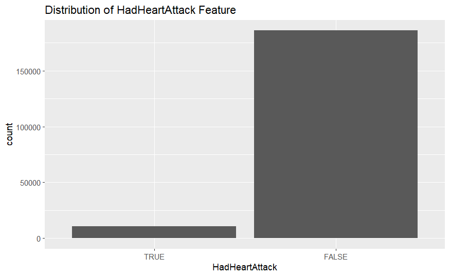

```r
ggplot(train) +
  aes(x = HadHeartAttack) +
  geom_bar() +
  scale_fill_brewer(palette = "Set3") +
  labs(title="Distribution of HadHeartAttack Feature")
```

We can see the data is vastly skewed as most medical data is since a majority of the human population does not have heart attacks but many still do.

This is the distribution for the Gender/Sex Feature

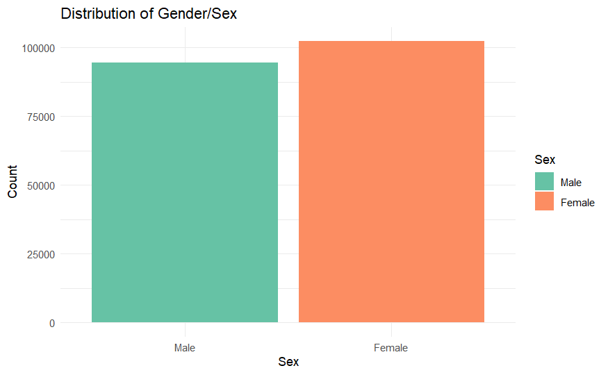

```r
ggplot(train) +
  aes(x = Sex, fill = Sex) +
  geom_bar() +
  scale_fill_brewer(palette = "Set2") +
  labs(title = "Distribution of Gender/Sex",x = "Sex",y = "Count",fill = "Sex") +
  theme_minimal()
```

In the above plot we see that there is an imbalance in observations betweeen males and females but comparitively to other feature distributions it is not as imbalanced.

This is the distribution for the GeneralHealth feature.

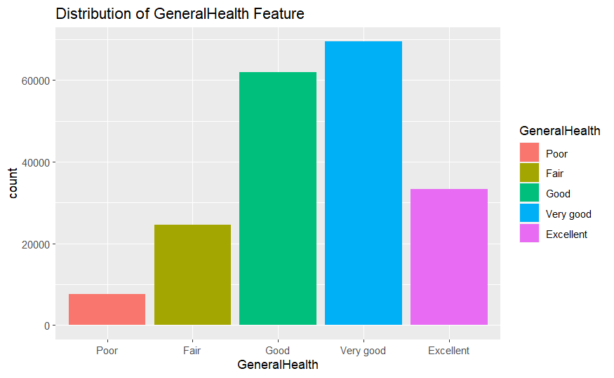

```r
ggplot(train) +
  aes(x = GeneralHealth, fill = GeneralHealth) +
  geom_bar() +
  labs(title="Distribution of GeneralHealth Feature")
```

In our data, we can see there is an imbalance of data to healthy individuals which makes sense since more people would be healthy than sick in the general public.

Next we look at the distribution of SmokerStatus.

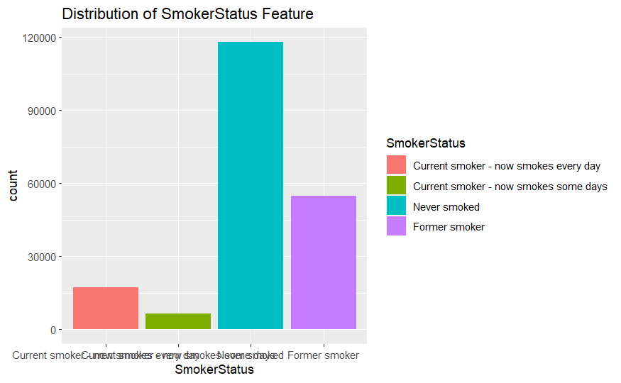

```r
ggplot(train) +
  aes(x = SmokerStatus , fill = SmokerStatus ) +
  geom_bar() +
  labs(title="Distribution of SmokerStatus Feature")
```

Another interesting distribution in our dataset was the SmokerStatus distribution where we have a high number of Never Smoked and Former Smoked individuals than the Current Smoker data. This makes sense since even though a high number of the human population smoke the non smoker population is still the vast majority of the population.

Distribution of general health among smokers and non smokers

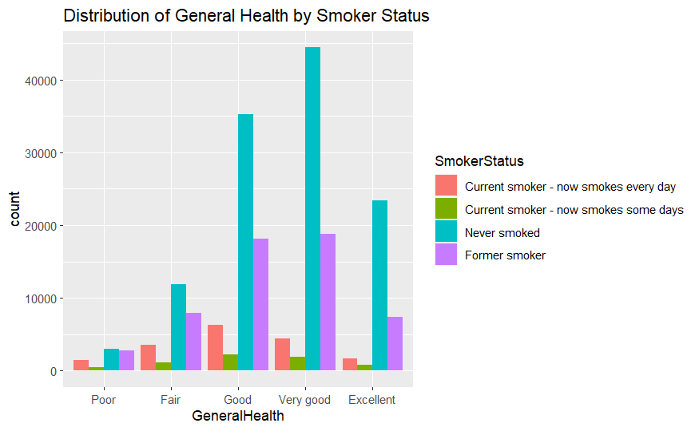

```r
ggplot(train, aes(x = GeneralHealth, fill = SmokerStatus)) +
  geom_bar(position = "dodge") +
  labs(title = "Distribution of General Health by Smoker Status")
```

In this plot we wanted to see if the SmokerStatus feature had any relation to the GeneralHealth feature that could give us insight into how other indicators could be represented in GeneralHealth. We see that the other categories other than Poor did have higher number of Never Smoked counts then the other SmokerStatus categories showing that Smoking Status does indicate poorer health but the great imbalance in data for the GeneralHealth category could be difficult for the models to learn this relationship.

Finally we visualize the distribution of the Race feature

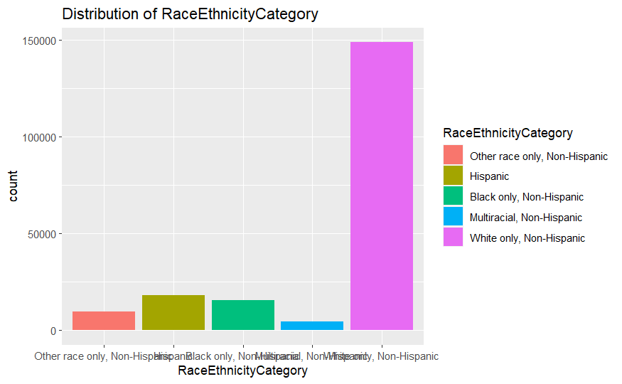

```r
ggplot(train) +
  aes(x = RaceEthnicityCategory , fill = RaceEthnicityCategory) +
  geom_bar()+
  labs(title = "Distribution of RaceEthnicityCategory")
```

The RaceEthnicityCategory had an interesting distribution where a majority of the observations were White only, Non-Hispanic. This is important to note since diseases or conditions for one ethnic group may skew results.

Another exploration to see the relation between some numerical variables with general health .

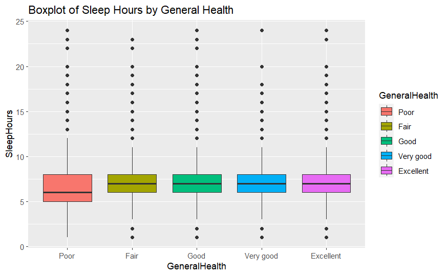

```r
numerical_vars <- c("SleepHours", "MentalHealthDays", "PhysicalHealthDays", "HeightInMeters", "WeightInKilograms", "BMI")
ggplot(train, aes(x = GeneralHealth, y = SleepHours, fill = GeneralHealth)) +
  geom_boxplot() +
  labs(title = "Boxplot of Sleep Hours by General Health")
```

This boxplot allows us to observe the central tendency, spread, and presence of outliers of SleepHours within each general health category.

In the plot we can see that the median sleep hours in poor health is lower than the other GeneralHealth Categories indicating less sleep may suggest poorer health.

Basic summary statistics (mean, median, quartiles, min, max) for the numerical variables.

```r
numerical_variables <- train[, c("SleepHours", "MentalHealthDays", "PhysicalHealthDays", "HeightInMeters", "WeightInKilograms", "BMI")]
summary_stats <- summary(numerical_variables)
summary_stats
```

```
   SleepHours     MentalHealthDays PhysicalHealthDays HeightInMeters  WeightInKilograms      BMI
 Min.   : 1.000   Min.   : 0.000   Min.   : 0.000     Min.   :0.910   Min.   : 28.12    Min.   :12.02
 1st Qu.: 6.000   1st Qu.: 0.000   1st Qu.: 0.000     1st Qu.:1.630   1st Qu.: 68.04    1st Qu.:24.27
 Median : 7.000   Median : 0.000   Median : 0.000     Median :1.700   Median : 81.65    Median :27.46
 Mean   : 7.021   Mean   : 4.172   Mean   : 4.115     Mean   :1.705   Mean   : 83.64    Mean   :28.67
 3rd Qu.: 8.000   3rd Qu.: 4.000   3rd Qu.: 3.000     3rd Qu.:1.780   3rd Qu.: 95.25    3rd Qu.:31.89
 Max.   :24.000   Max.   :30.000   Max.   :30.000     Max.   :2.410   Max.   :292.57    Max.   :97.65
```

We can see that the statistics do generally make sense except there definitely are outlier values in each of the numerical variable when you compare the 3rd quartile and the max value.

The following scatter plot visualizes the relationship between BMI (Body Mass Index) and the number of Physical Health Days but categorized with the GeneralHealth feature.

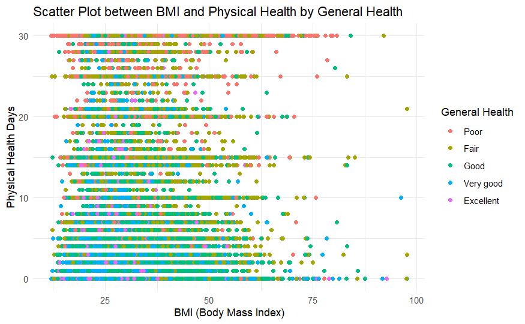

```r
ggplot(train, aes(x = BMI, y = PhysicalHealthDays, color = GeneralHealth)) +
  geom_point() +
  labs(title = "Scatter Plot between BMI and Physical Health by General Health",
    x = "BMI (Body Mass Index)",y = "Physical Health Days",color = "General Health") +
  theme_minimal()
```

### Identify variables that may be useful to predict the outcome.

As we all know age and heart attack are most of the time related/associated to see for the prediction.

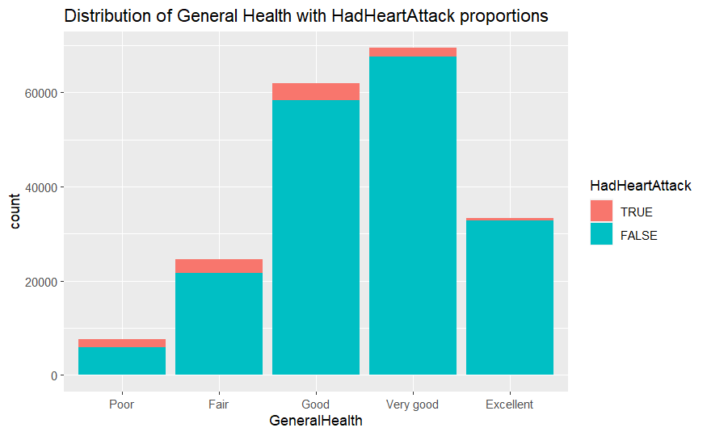

```r
ggplot(train) +
  aes(fill=HadHeartAttack , x=GeneralHealth) +
  geom_bar()+
  labs(title = "Distribution of General Health with HadHeartAttack proportions")
```

The box plot compares and help visualize the distribution of BMI between individuals who had a heart attack and those who didn’t. It helps identify any differences in BMI distribution based on heart attack status.

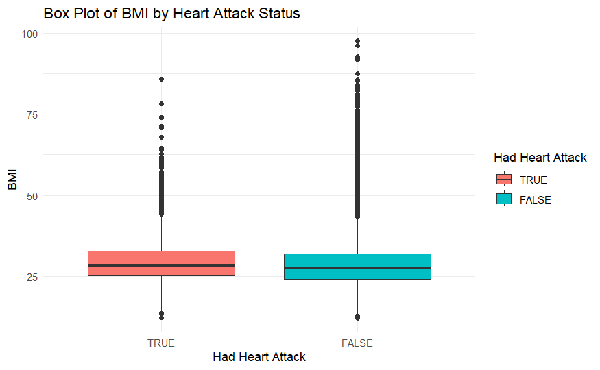

```r
ggplot(train, aes(x = HadHeartAttack, y = BMI, fill = HadHeartAttack)) +
  geom_boxplot() +
  labs(title = "Box Plot of BMI by Heart Attack Status",x = "Had Heart Attack",
       y = "BMI",fill = "Had Heart Attack") +
  theme_minimal()
```

It looks like the ‘Had Heart Attack’ group exhibits a slightly higher median BMI compared to the ‘No Heart Attack’ group but it is not statistically significant enough. There are more outliers in the False distribution of HadHeartAttack values but that could be because of the imbalance in the HadHeartAttack distribution.

The following histogram displays the distribution of individuals across different age categories, stacked by whether they had a heart attack.

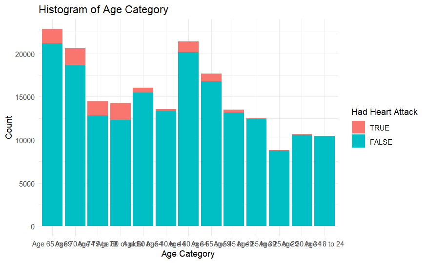

```r
ggplot(train, aes(x = AgeCategory, fill = HadHeartAttack)) +
  geom_bar(position = "stack") +
  labs(title = "Histogram of Age Category",x = "Age Category",y = "Count",
       fill = "Had Heart Attack") +
  theme_minimal()
```

Let us look at the distribution of HadHeartAttack based on GeneralHealth and Sex.

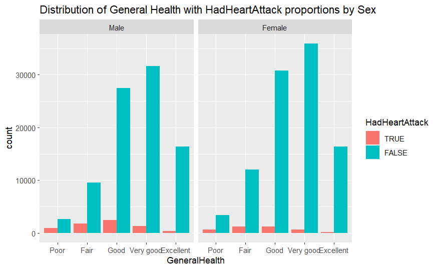

```r
ggplot(train, aes(x = GeneralHealth, fill = HadHeartAttack)) +
  geom_bar(position = "dodge") +
  facet_wrap(~Sex) +
  labs(title = "Distribution of General Health with HadHeartAttack proportions by Sex")
```

In this plot we can see that when we break up the GeneralHealth to HadHeartAttack relationship by Sex we begin to see that more men do have more heartAttacks then woman and we also see that the dataset does have a good balance of observations between the two populations.

Let’s revisit the Distribution of Race/Ethnicity but with its relationshipt to our outcome variable.

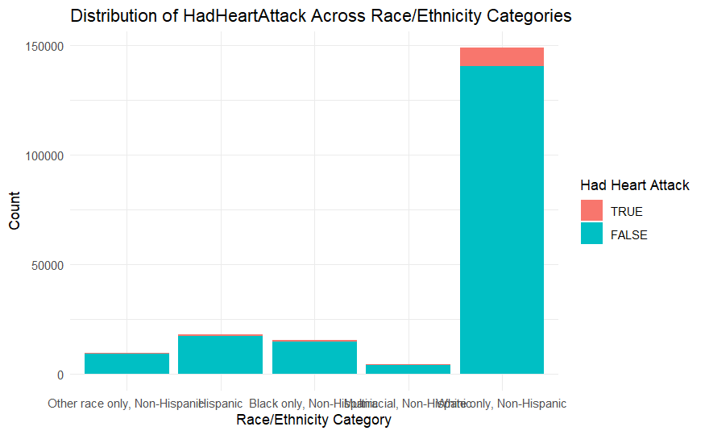

```r
ggplot(train) +
  aes(x = RaceEthnicityCategory, fill = HadHeartAttack) +
  geom_bar() +
  labs(title = "Distribution of HadHeartAttack Across Race/Ethnicity Categories",x = "Race/Ethnicity Category",
       y = "Count",
    fill = "Had Heart Attack") +
  theme_minimal()
```

It appears that the white non-Hispanic ethnicity had a higher prevalence of heart attacks but due to the imbalance in the dataset this may not imply any causal relationship.

The following boxplot visually displays the distribution of sleep hours for individuals with and without a reported heart attack

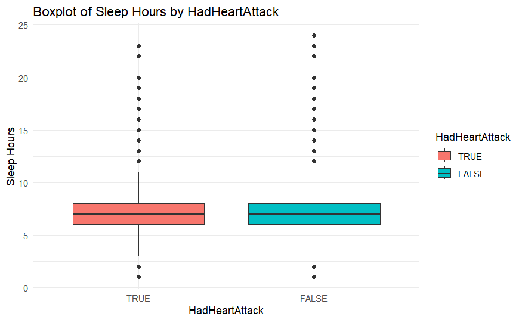

```r
ggplot(train, aes(x = HadHeartAttack, y = SleepHours, fill = HadHeartAttack)) +
  geom_boxplot() +
  labs(title = "Boxplot of Sleep Hours by HadHeartAttack",
    x = "HadHeartAttack",y = "Sleep Hours",fill = "HadHeartAttack") +
  theme_minimal()
```

We can see there are no significant differences in sleep hours in those individuals with and without a reported heart attack

The next plot shows the distribution of COVID positive cases among individuals with and without a history of heart attack.

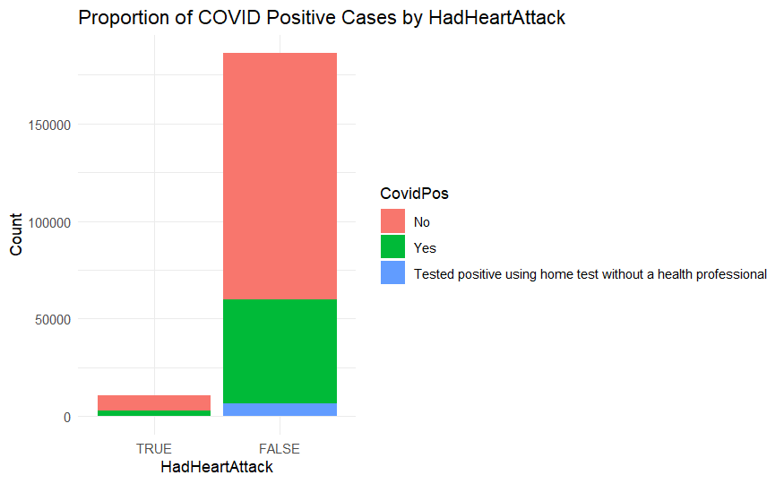

```r
ggplot(train, aes(x = HadHeartAttack, fill = CovidPos)) +
  geom_bar() +
  labs(title = "Proportion of COVID Positive Cases by HadHeartAttack",
    x = "HadHeartAttack",y = "Count",fill = "CovidPos") +
  theme_minimal()
```

The next plot is a scatter Plot of Height vs Weight with categories by the HadHeartAttack Feature.

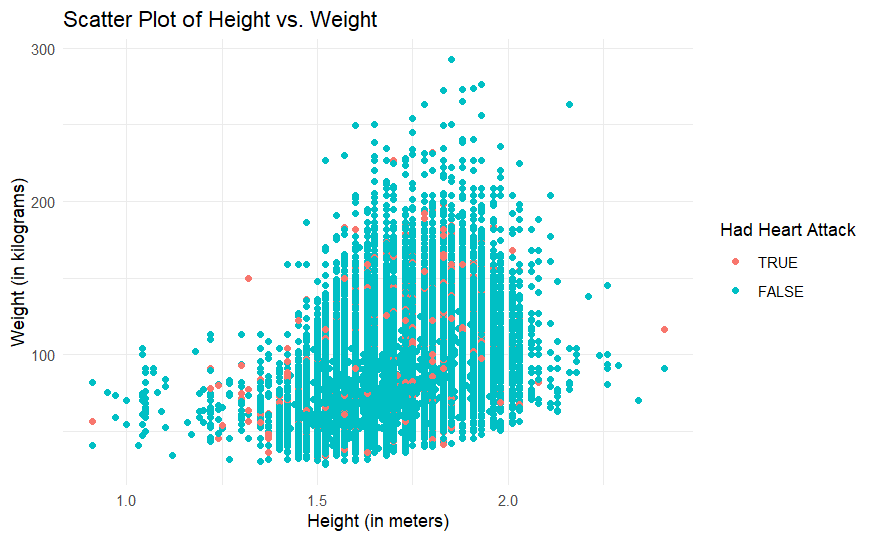

```r
ggplot(train, aes(x = HeightInMeters, y = WeightInKilograms, color = HadHeartAttack)) +
  geom_point() +
  labs(title = "Scatter Plot of Height vs. Weight",x = "Height (in meters)",y = "Weight (in kilograms)",
       color = "Had Heart Attack") +
  theme_minimal()
```

There is no linear pattern between height and weight. In addition the distribution of heart attack seems allover. However we do see a slight cluster for observations < 2 meter height and <100 kg weight than others.

### Summary of Exploration

There were many features in this dataset so we could not do many explorations but based on the major feautres we thought may stick out for an individual to have had a heart attack we can see that there are some relationships between the features and the HadHeartAttack feature. The vast imbalance in the dataset for our outcome variable and many of the features may make it hard for our models to accurately predict if an individual has HadHeartAttack but this may give insights into what features really are the key risk factors/indicators that may cause heart disease / heart attacks.

# Methodology

In order to solve our task of finding the key indicators/risk factors that indicate if an individual has had a heart attack, we chose to use three different models: logistic regression, random forest, and XGBoost. Comparing the feature importance from these 3 models can help find the best indicators/risk factors.

The logistic regression model is commonly used for binary classification making it suitable for our problem of finding if an individual has had a heart attack and since the algorithm provides probabilities for each feature’s likelihood of having a heart attack this makes the model interpretable for accomplishing our task.

The random forest model can capture complex relationships between features and is less prone to overfitting which is great for medical data such as ours that will have imbalanced data. The random forest algorithm creates multiple decision trees trained on a subset of the data which will help capture different complex relationships between the features and then a final decision is made through a voting mechanism from all the trees. This model also provides us with the feature importances gleaned from the multiple trained trees which will be helpful as we want to find the key indicators/risk factors for an individual having a heart attack for our task.

# Modeling and Results

## Logistic Regression Model

### Training

```r
model.logReg <- glm(HadHeartAttack ~ ., train, family = "binomial")
summary(model.logReg)
```

```
Call:
glm(formula = HadHeartAttack ~ ., family = "binomial", data = train)

Coefficients:
                                                                             Estimate Std. Error z value
(Intercept)                                                                 1.768e+00  8.115e-01   2.179
SexFemale                                                                   6.975e-01  3.429e-02  20.342
GeneralHealthFair                                                           1.467e-01  4.584e-02   3.200
GeneralHealthGood                                                           3.802e-01  5.058e-02   7.518
GeneralHealthVery good                                                      7.121e-01  5.602e-02  12.711
GeneralHealthExcellent                                                      1.022e+00  7.049e-02  14.496
PhysicalHealthDays                                                          1.545e-03  1.431e-03   1.080
MentalHealthDays                                                           -2.920e-03  1.604e-03  -1.820
LastCheckupTime5 or more years ago                                          7.189e-02  1.139e-01   0.631
LastCheckupTimeWithin past 2 years (1 year but less than 2 years ago)       8.188e-03  9.182e-02   0.089
LastCheckupTimeWithin past year (anytime less than 12 months ago)          -2.217e-01  7.722e-02  -2.871
PhysicalActivitiesTRUE                                                      3.070e-02  2.701e-02   1.137
SleepHours                                                                  2.308e-02  7.057e-03   3.270
RemovedTeeth1 to 5                                                          1.429e-01  3.347e-02   4.271
RemovedTeethAll                                                            -2.463e-01  4.044e-02  -6.091
RemovedTeethNone of them                                                    2.519e-01  3.545e-02   7.104
HadAnginaTRUE                                                              -2.408e+00  2.571e-02 -93.673
HadStrokeTRUE                                                              -8.712e-01  3.480e-02 -25.036
HadAsthmaTRUE                                                               1.559e-02  3.292e-02   0.474
HadCOPDTRUE                                                                -9.023e-03  3.402e-02  -0.265
HadDepressiveDisorderTRUE                                                  -2.760e-02  3.279e-02  -0.842
HadKidneyDiseaseTRUE                                                       -6.046e-02  3.829e-02  -1.579
HadDiabetesYes                                                             -2.799e-01  2.766e-02 -10.118
HadDiabetesNo, pre-diabetes or borderline diabetes                         -7.862e-02  6.946e-02  -1.132
HadDiabetesYes, but only during pregnancy (female)                         -1.524e-01  1.843e-01  -0.827
DeafOrHardOfHearingTRUE                                                    -3.021e-02  3.231e-02  -0.935
BlindOrVisionDifficultyTRUE                                                -1.023e-01  4.154e-02  -2.464
DifficultyConcentratingTRUE                                                -6.229e-02  3.737e-02  -1.667
DifficultyWalkingTRUE                                                      -7.708e-02  3.182e-02  -2.423
DifficultyDressingBathingTRUE                                               3.862e-02  5.014e-02   0.770
DifficultyErrandsTRUE                                                      -7.982e-02  4.170e-02  -1.914
SmokerStatusCurrent smoker - now smokes some days                           1.478e-02  6.677e-02   0.221
SmokerStatusNever smoked                                                    4.338e-01  4.178e-02  10.384
SmokerStatusFormer smoker                                                   2.267e-01  4.028e-02   5.628
ECigaretteUsageNever used e-cigarettes in my entire life                    7.579e-02  8.667e-02   0.874
```

[output cut: 89 more lines]

```
TetanusLast10TdapYes, received tetanus shot but not sure what type         0.027080 *
TetanusLast10TdapNo, did not receive any tetanus shot in the past 10 years 0.002207 **
HighRiskLastYearTRUE                                                       0.121483
CovidPosYes                                                                0.213170
CovidPosTested positive using home test without a health professional      0.003894 **
---
Signif. codes:  0 ‘***’ 0.001 ‘**’ 0.01 ‘*’ 0.05 ‘.’ 0.1 ‘ ’ 1

(Dispersion parameter for binomial family taken to be 1)

    Null deviance: 82793  on 196816  degrees of freedom
Residual deviance: 56823  on 196753  degrees of freedom
AIC: 56951

Number of Fisher Scoring iterations: 8
```

### Feature Importance

```r
coeff_logReg <- coef(summary(model.logReg))
coeff_logReg <- as.data.frame(coeff_logReg)
important_features_logReg <- coeff_logReg %>%
  arrange(desc(abs(Estimate)))
important_features_logReg
```

|  | Estimate | Std. Error | z value | Pr(>\|z\|) |
| --- | --- | --- | --- | --- |
| HadAnginaTRUE | -2.408044e+00 | 0.025707019 | -93.672625712 | 0.000000e+00 |
| AgeCategoryAge 25 to 29 | 1.960795e+00 | 0.176311732 | 11.121185013 | 9.894889e-29 |
| AgeCategoryAge 18 to 24 | 1.900931e+00 | 0.163837432 | 11.602541454 | 4.000195e-31 |
| (Intercept) | 1.767970e+00 | 0.811489482 | 2.178672427 | 2.935601e-02 |
| AgeCategoryAge 30 to 34 | 1.501144e+00 | 0.126143979 | 11.900244056 | 1.180016e-32 |
| AgeCategoryAge 35 to 39 | 1.301443e+00 | 0.103055378 | 12.628576525 | 1.469118e-36 |
| GeneralHealthExcellent | 1.021815e+00 | 0.070490807 | 14.495726459 | 1.289311e-47 |
| AgeCategoryAge 40 to 44 | 1.009593e+00 | 0.083731313 | 12.057528625 | 1.770152e-33 |
| HadStrokeTRUE | -8.711518e-01 | 0.034795477 | -25.036352463 | 2.458524e-138 |
| GeneralHealthVery good | 7.121101e-01 | 0.056022520 | 12.711140611 | 5.128095e-37 |

[output cut: 54 more lines]

### Predictions

```r
threshold=0.5
logReg_scores = predict(model.logReg, test, type = "response") %>%
  as_tibble() %>%
  mutate("FALSE"=value) %>%
  mutate("TRUE"=1-value) %>%
  mutate(Prediction=factor(if_else(`TRUE` > `FALSE`, TRUE, FALSE), levels=c(TRUE, FALSE)),
        Label=test$HadHeartAttack)
glimpse(logReg_scores)
```

```
Rows: 49,205
Columns: 5
$ value      <dbl> 0.9243138, 0.9558718, 0.9783823, 0.3803722, 0.9306520, 0.9599255, 0.9612577, 0.80057…
$ `FALSE`    <dbl> 0.9243138, 0.9558718, 0.9783823, 0.3803722, 0.9306520, 0.9599255, 0.9612577, 0.80057…
$ `TRUE`     <dbl> 0.075686175, 0.044128210, 0.021617700, 0.619627804, 0.069348035, 0.040074525, 0.0387…
$ Prediction <fct> FALSE, FALSE, FALSE, TRUE, FALSE, FALSE, FALSE, FALSE, FALSE, FALSE, TRUE, FALSE, FA…
$ Label      <fct> FALSE, FALSE, FALSE, FALSE, FALSE, FALSE, FALSE, FALSE, FALSE, FALSE, TRUE, FALSE, F…
```

### Metrics

```r
metrics = metric_set(accuracy, precision, sensitivity, specificity)
measures_logReg <- metrics(logReg_scores, truth=Label, estimate=Prediction)
measures_logReg
```

| .metric | .estimator | .estimate |
| --- | --- | --- |
| accuracy | binary | 0.9472208 |
| precision | binary | 0.5829103 |
| sensitivity | binary | 0.2466881 |
| specificity | binary | 0.9893777 |

### ROC curve and AUC:

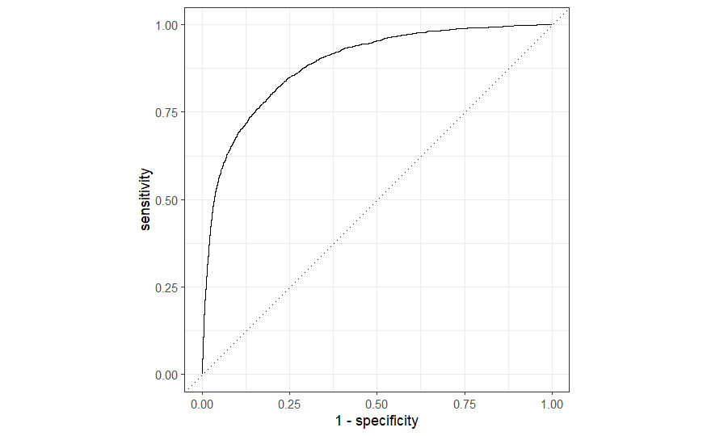

```r
autoplot(roc_curve(logReg_scores, Label, `TRUE`))
```

```r
logReg_roc_auc <- roc_auc(logReg_scores, Label, `TRUE`)
logReg_roc_auc
```

| .metric | .estimator | .estimate |
| --- | --- | --- |
| roc_auc | binary | 0.8881814 |

## Random Forest Model

### Training

```r
model.rf = randomForest(HadHeartAttack ~ ., train, na.action=na.omit)
summary(model.rf)
```

```
                Length Class  Mode
call                 4 -none- call
type                 1 -none- character
predicted       196817 factor numeric
err.rate          1500 -none- numeric
confusion            6 -none- numeric
votes           393634 matrix numeric
oob.times       196817 -none- numeric
classes              2 -none- character
importance          33 -none- numeric
importanceSD         0 -none- NULL
localImportance      0 -none- NULL
proximity            0 -none- NULL
ntree                1 -none- numeric
mtry                 1 -none- numeric
forest              14 -none- list
y               196817 factor numeric
test                 0 -none- NULL
inbag                0 -none- NULL
terms                3 terms  call
```

### Feature Importance

```r
important_features_rf <- importance(model.rf)
# important_features_rf
# Sort the features
important_features_rf_df <- as.data.frame(important_features_rf)
important_features_rf_df$Feature <- rownames(important_features_rf_df)
sorted_importance_rf <- important_features_rf_df[order(-important_features_rf_df$MeanDecreaseGini), ]
sorted_importance_rf$Feature <- NULL # Feature column was duplicated in the data frame
sorted_importance_rf
```

|  | MeanDecreaseGini |
| --- | --- |
| HadAngina | 3102.92229 |
| BMI | 1806.13148 |
| WeightInKilograms | 1575.01461 |
| AgeCategory | 1334.03760 |
| HeightInMeters | 1228.10601 |
| SleepHours | 978.86417 |
| PhysicalHealthDays | 780.15008 |
| TetanusLast10Tdap | 727.79471 |
| GeneralHealth | 696.56133 |
| RemovedTeeth | 642.29347 |

[output cut: 23 more lines]

### Predictions

```r
rf_scores = predict(model.rf, test, type = "prob") %>%
  as_tibble() %>%
 mutate(Prediction=factor(if_else(`TRUE` > `FALSE`, TRUE, FALSE), levels=c(TRUE, FALSE)),
        Label=test$HadHeartAttack)
glimpse(rf_scores)
```

```
Rows: 49,205
Columns: 4
$ `TRUE`     <matrix> 0.088, 0.066, 0.022, 0.486, 0.060, 0.032, 0.042, 0.136, 0.012, 0.086, 0.424, 0.15…
$ `FALSE`    <matrix> 0.912, 0.934, 0.978, 0.514, 0.940, 0.968, 0.958, 0.864, 0.988, 0.914, 0.576, 0.84…
$ Prediction <fct> FALSE, FALSE, FALSE, FALSE, FALSE, FALSE, FALSE, FALSE, FALSE, FALSE, FALSE, FALSE, …
$ Label      <fct> FALSE, FALSE, FALSE, FALSE, FALSE, FALSE, FALSE, FALSE, FALSE, FALSE, TRUE, FALSE, F…
```

### Metrics

```r
metrics = metric_set(accuracy, precision, sensitivity, specificity)
measures_rf <- metrics(rf_scores, truth=Label, estimate=Prediction)
measures_rf
```

| .metric | .estimator | .estimate |
| --- | --- | --- |
| accuracy | binary | 0.9474850 |
| precision | binary | 0.6417910 |
| sensitivity | binary | 0.1693520 |
| specificity | binary | 0.9943118 |

### ROC curve and AUC:

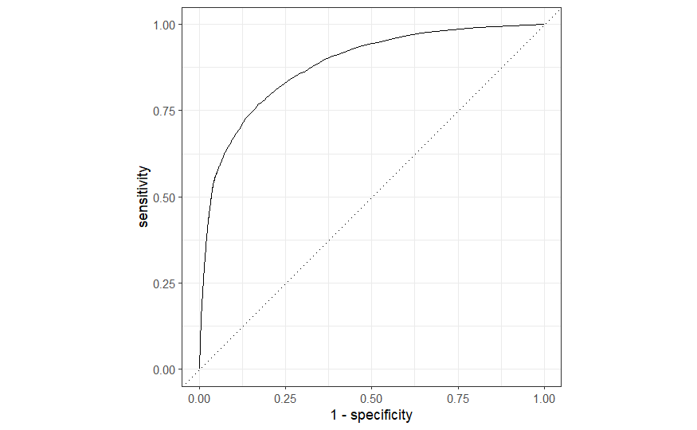

```r
autoplot(roc_curve(rf_scores, Label, `TRUE`))
```

```r
rf_roc_auc <- roc_auc(rf_scores, Label, `TRUE`)
rf_roc_auc
```

| .metric | .estimator | .estimate |
| --- | --- | --- |
| roc_auc | binary | 0.8803854 |

## XGBoost model

### Training

```r
train_labels <- train %>%
  select(HadHeartAttack)
train_features <- train %>%
  select(-HadHeartAttack)

test_labels <- test %>%
  select(HadHeartAttack)
test_features <- test%>%
  select(-HadHeartAttack)

xgb_train <- xgb.DMatrix(data=data.matrix(train_features), label=data.matrix(train_labels == TRUE))
xgb_test <- xgb.DMatrix(data=data.matrix(test_features), label=data.matrix(test_labels == TRUE))

model.xgb = xgboost(data=xgb_train,
                   params=list(objective="binary:logistic", max.depth=5, early_stopping_rounds=15, gamma=1),
                   nrounds=100)
```

```
[16:57:02] WARNING: src/learner.cc:767:
Parameters: { "early_stopping_rounds" } are not used.
```

### Feature Importance

```r
important_features_xgb <- xgb.importance(colnames(data.matrix(train_features)), model=model.xgb)
important_features_xgb
```

| Feature | Gain | Cover | Frequency |
| --- | --- | --- | --- |
| HadAngina | 0.546066975 | 0.083960327 | 0.031714569 |
| AgeCategory | 0.077161626 | 0.133519039 | 0.083250743 |
| ChestScan | 0.063426182 | 0.070372857 | 0.025272547 |
| GeneralHealth | 0.051242971 | 0.065710211 | 0.052031715 |
| HadStroke | 0.043467041 | 0.055573582 | 0.028245788 |
| BMI | 0.029044964 | 0.139882010 | 0.149157582 |
| RemovedTeeth | 0.025142671 | 0.024153076 | 0.027750248 |
| Sex | 0.023866653 | 0.033696764 | 0.023290387 |
| WeightInKilograms | 0.019924816 | 0.099268619 | 0.103072349 |
| SleepHours | 0.014995765 | 0.035572577 | 0.062438057 |

[output cut: 23 more lines]

### Predictions

```r
xgb_scores = predict(model.xgb, xgb_test, type = "prob") %>%
  as_tibble() %>%
  mutate("TRUE"=value) %>%
  mutate("FALSE"=1-value) %>%
  mutate(Prediction=factor(if_else(`TRUE` > `FALSE`, TRUE, FALSE), levels=c(TRUE, FALSE)),
        Label=test$HadHeartAttack)
glimpse(xgb_scores)
```

```
Rows: 49,205
Columns: 5
$ value      <dbl> 0.073213190, 0.045215726, 0.008086908, 0.417200327, 0.073961183, 0.038601357, 0.0510…
$ `TRUE`     <dbl> 0.073213190, 0.045215726, 0.008086908, 0.417200327, 0.073961183, 0.038601357, 0.0510…
$ `FALSE`    <dbl> 0.9267868, 0.9547843, 0.9919131, 0.5827997, 0.9260388, 0.9613986, 0.9489633, 0.85646…
$ Prediction <fct> FALSE, FALSE, FALSE, FALSE, FALSE, FALSE, FALSE, FALSE, FALSE, FALSE, TRUE, FALSE, F…
$ Label      <fct> FALSE, FALSE, FALSE, FALSE, FALSE, FALSE, FALSE, FALSE, FALSE, FALSE, TRUE, FALSE, F…
```

### Metrics

```r
metrics = metric_set(accuracy, precision, sensitivity, specificity)
measures_xgb <- metrics(xgb_scores, truth=Label, estimate=Prediction)
measures_xgb
```

| .metric | .estimator | .estimate |
| --- | --- | --- |
| accuracy | binary | 0.9484808 |
| precision | binary | 0.6149733 |
| sensitivity | binary | 0.2470462 |
| specificity | binary | 0.9906921 |

### ROC curve and AUC:

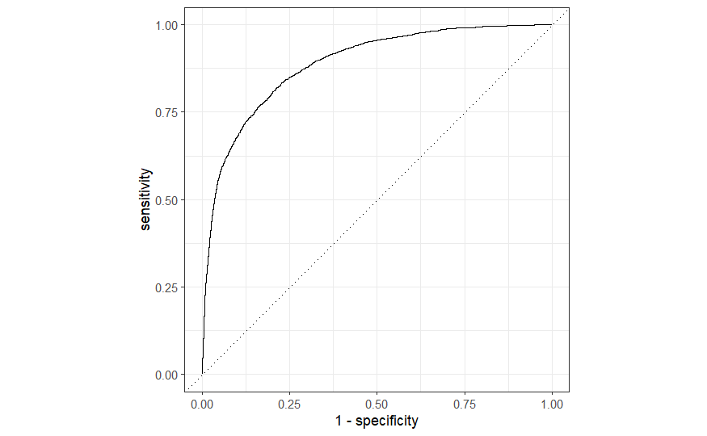

```r
autoplot(roc_curve(xgb_scores, Label, `TRUE`))
```

```r
xgb_roc_auc <- roc_auc(xgb_scores, Label, `TRUE`)
xgb_roc_auc
```

| .metric | .estimator | .estimate |
| --- | --- | --- |
| roc_auc | binary | 0.8882757 |

# Evaluation

```r
# Feature Importance
important_features_logReg
```

|  | Estimate | Std. Error | z value | Pr(>\|z\|) |
| --- | --- | --- | --- | --- |
| HadAnginaTRUE | -2.408044e+00 | 0.025707019 | -93.672625712 | 0.000000e+00 |
| AgeCategoryAge 25 to 29 | 1.960795e+00 | 0.176311732 | 11.121185013 | 9.894889e-29 |
| AgeCategoryAge 18 to 24 | 1.900931e+00 | 0.163837432 | 11.602541454 | 4.000195e-31 |
| (Intercept) | 1.767970e+00 | 0.811489482 | 2.178672427 | 2.935601e-02 |
| AgeCategoryAge 30 to 34 | 1.501144e+00 | 0.126143979 | 11.900244056 | 1.180016e-32 |
| AgeCategoryAge 35 to 39 | 1.301443e+00 | 0.103055378 | 12.628576525 | 1.469118e-36 |
| GeneralHealthExcellent | 1.021815e+00 | 0.070490807 | 14.495726459 | 1.289311e-47 |
| AgeCategoryAge 40 to 44 | 1.009593e+00 | 0.083731313 | 12.057528625 | 1.770152e-33 |
| HadStrokeTRUE | -8.711518e-01 | 0.034795477 | -25.036352463 | 2.458524e-138 |
| GeneralHealthVery good | 7.121101e-01 | 0.056022520 | 12.711140611 | 5.128095e-37 |

[output cut: 54 more lines]

```r
sorted_importance_rf
```

|  | MeanDecreaseGini |
| --- | --- |
| HadAngina | 3102.92229 |
| BMI | 1806.13148 |
| WeightInKilograms | 1575.01461 |
| AgeCategory | 1334.03760 |
| HeightInMeters | 1228.10601 |
| SleepHours | 978.86417 |
| PhysicalHealthDays | 780.15008 |
| TetanusLast10Tdap | 727.79471 |
| GeneralHealth | 696.56133 |
| RemovedTeeth | 642.29347 |

[output cut: 23 more lines]

```r
important_features_xgb
```

| Feature | Gain | Cover | Frequency |
| --- | --- | --- | --- |
| HadAngina | 0.546066975 | 0.083960327 | 0.031714569 |
| AgeCategory | 0.077161626 | 0.133519039 | 0.083250743 |
| ChestScan | 0.063426182 | 0.070372857 | 0.025272547 |
| GeneralHealth | 0.051242971 | 0.065710211 | 0.052031715 |
| HadStroke | 0.043467041 | 0.055573582 | 0.028245788 |
| BMI | 0.029044964 | 0.139882010 | 0.149157582 |
| RemovedTeeth | 0.025142671 | 0.024153076 | 0.027750248 |
| Sex | 0.023866653 | 0.033696764 | 0.023290387 |
| WeightInKilograms | 0.019924816 | 0.099268619 | 0.103072349 |
| SleepHours | 0.014995765 | 0.035572577 | 0.062438057 |

[output cut: 23 more lines]

One thing to note is that the Logistic Regresion feature importance show each categories estimate whereas the Random Forest and XGBoost models only show the features importance overall.

```r
# METRICS
# measures_logReg
# measures_rf
# measures_xgb
measures <- bind_rows(
  mutate(Model="Logistic Regression", measures_logReg),
  mutate(Model="Random Forest", measures_rf),
  mutate(Model="XGBoost", measures_xgb),
)
measures
```

| .metric | .estimator | .estimate | Model |
| --- | --- | --- | --- |
| accuracy | binary | 0.9472208 | Logistic Regression |
| precision | binary | 0.5829103 | Logistic Regression |
| sensitivity | binary | 0.2466881 | Logistic Regression |
| specificity | binary | 0.9893777 | Logistic Regression |
| accuracy | binary | 0.9474850 | Random Forest |
| precision | binary | 0.6417910 | Random Forest |
| sensitivity | binary | 0.1693520 | Random Forest |
| specificity | binary | 0.9943118 | Random Forest |
| accuracy | binary | 0.9484808 | XGBoost |
| precision | binary | 0.6149733 | XGBoost |

[output cut: 2 more lines]

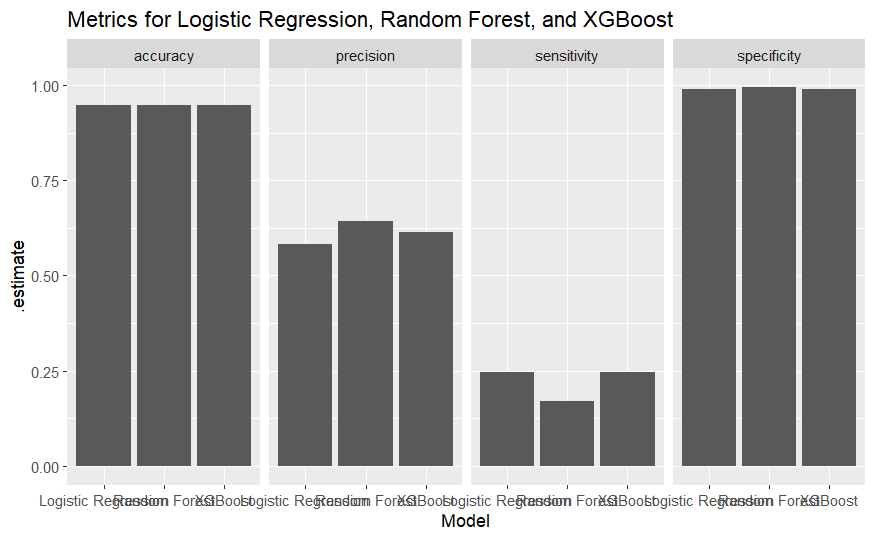

```r
ggplot(measures)+
  aes(x=Model, y=.estimate)+
  geom_bar(position="dodge", stat = "identity")+
  facet_grid(~.metric) +
  labs(title = "Metrics for Logistic Regression, Random Forest, and XGBoost")
```

The metrics show that each of the models resulted in similar performances. The Accuracy was very good and so was the specificity which should not be a surprise since there were many more HadHeartAttack=FALSE observations then TRUE. An interesting thing to note is that the sensitivity of the random forest was lower than the other two models which had very similar sensitivy metrics. This means that the random forest model is only finding 0.1693520 or 16.9% of HadHeartAttack observations vs approximately 25% for the other two models. The low value of the sensitivity metric is most likely due to the great imbalance in the dataset but we can see that LogisticRegression and XGBoost did slightly better at predicting if an individual had a heart attack then random forest.

```r
# ROC AUCs
result_AUCs <- data.frame(model = character(), AUC = numeric())
result_AUCs <- rbind(result_AUCs, data.frame(model = "Logistic Regression", AUC=logReg_roc_auc$.estimate))
result_AUCs <- rbind(result_AUCs, data.frame(model = "Random Forest", AUC=rf_roc_auc$.estimate))
result_AUCs <- rbind(result_AUCs, data.frame(model = "XGBoost", AUC=xgb_roc_auc$.estimate))
result_AUCs
```

| model | AUC |
| --- | --- |
| Logistic Regression | 0.8881814 |
| Random Forest | 0.8803854 |
| XGBoost | 0.8882757 |

The area under the curve of the receiver operating curve is approximately the same for all three models at ~88% showing the models did train well on the imbalanced data.